# High Garden Coffee - Analitica de consumo domestico de cafe (1990-2020)

Reto tecnico de ingenieria de ML - NTT DATA

Contexto de negocio: High Garden Coffee es una exportadora internacional de cafe. El area de innovacion quiere aprovechar una base historica de consumo domestico de cafe (1990-2020, 55 paises, distintos tipos de cafe) para identificar tendencias, informacion clave y una posible senal de precios futuros que den ventaja competitiva.

Idea central del analisis: para una exportadora, el consumo domestico en los paises productores es la otra cara del excedente exportable. A mas consumo domestico, menos cafe disponible para exportar (todo lo demas constante). Por eso el analisis recorre: tendencias, crecimiento por pais, segmentacion de paises productores, forecasting de consumo, un indice de presion de precios (simulado, con metodologia explicita) y deteccion de eventos anomalos, cerrando con recomendaciones de negocio y una propuesta bonus de chatbot con IA generativa.

```python
import warnings
warnings.filterwarnings('ignore')

import json
from pathlib import Path

import numpy as np
import pandas as pd
import matplotlib.pyplot as plt
import seaborn as sns
from sklearn.preprocessing import StandardScaler
from sklearn.cluster import KMeans
from sklearn.decomposition import PCA
from sklearn.metrics import silhouette_score
from statsmodels.tsa.holtwinters import ExponentialSmoothing

sns.set_theme(style="whitegrid")
plt.rcParams["figure.figsize"] = (10, 5)

RANDOM_STATE = 42
np.random.seed(RANDOM_STATE)

# Rutas relativas robustas: no dependen del directorio desde el que se invoque nbconvert.
BASE_DIR = Path.cwd()
DATA_PATH = BASE_DIR / "coffee_db.parquet"
CHARTS_DIR = BASE_DIR / "charts"
OUTPUTS_DIR = BASE_DIR / "outputs"
CHARTS_DIR.mkdir(exist_ok=True)
OUTPUTS_DIR.mkdir(exist_ok=True)

print("BASE_DIR:", BASE_DIR)
print("DATA_PATH existe:", DATA_PATH.exists())
```

```
BASE_DIR: C:\Users\arroy\Downloads\PRUEBA JOE NTT DATA
DATA_PATH existe: True
```

```python
df_wide = pd.read_parquet(DATA_PATH)
print("Shape:", df_wide.shape)
print("Nulos por columna:", df_wide.isnull().sum().sum())
df_wide.head()
```

```
Shape: (55, 33)
Nulos por columna: 0
```

|  | Country | Coffee type | 1990/91 | 1991/92 | 1992/93 | 1993/94 | 1994/95 | 1995/96 | 1996/97 | 1997/98 | ... | 2011/12 | 2012/13 | 2013/14 | 2014/15 | 2015/16 | 2016/17 | 2017/18 | 2018/19 | 2019/20 | Total_domestic_consumption |
| --- | --- | --- | --- | --- | --- | --- | --- | --- | --- | --- | --- | --- | --- | --- | --- | --- | --- | --- | --- | --- | --- |
| 0 | Angola | Robusta/Arabica | 1200000 | 1800000 | 2100000 | 1200000 | 1500000 | 600000 | 1200000 | 2400000 | ... | 1800000 | 1800000 | 1800000 | 1800000 | 1800000 | 1800000 | 1800000 | 1800000 | 1800000 | 46500000 |
| 1 | Bolivia (Plurinational State of) | Arabica | 1500000 | 1620000 | 1650000 | 1710000 | 1770000 | 1830000 | 1890000 | 1950000 | ... | 2940000 | 3030000 | 3120000 | 3210000 | 3300000 | 3420000 | 3510000 | 3600000 | 3660000 | 75180000 |
| 2 | Brazil | Arabica/Robusta | 492000000 | 510000000 | 534000000 | 546000000 | 558000000 | 606000000 | 660000000 | 690000000 | ... | 1183200000 | 1219800000 | 1205100000 | 1219980000 | 1230480000 | 1273500000 | 1319820000 | 1332000000 | 1320000000 | 27824700000 |
| 3 | Burundi | Arabica/Robusta | 120000 | 96000 | 102000 | 114600 | 120000 | 120000 | 120000 | 120000 | ... | 120000 | 120000 | 120000 | 120000 | 120000 | 120000 | 120000 | 120000 | 120000 | 3412020 |
| 4 | Ecuador | Arabica/Robusta | 21000000 | 21000000 | 21000000 | 21000000 | 21000000 | 21000000 | 18000000 | 18000000 | ... | 9000000 | 9000000 | 9300000 | 9300000 | 9300000 | 9300000 | 9300000 | 9300000 | 8940000 | 381540000 |

5 rows × 33 columns

## 1. Decisiones de preparacion de datos

Tipo de cafe (Coffee type): el dataset trae 4 valores: `Arabica`, `Robusta`, `Arabica/Robusta`, `Robusta/Arabica`. El orden de las etiquetas mixtas no esta documentado de forma confiable en la fuente como indicador de variedad predominante, asi que para el analisis principal (tendencias, clustering, forecasting por tipo) se agregan `Arabica/Robusta` y `Robusta/Arabica` en una sola categoria `Mixto`. Se conserva la columna original `Coffee type` sin modificar por si en el futuro se confirma que el orden si es significativo.

Unidades de consumo: el enunciado del reto dice que el consumo esta "en tazas", pero la estructura de esta serie (55 paises productores, 1990-2020, valores redondeados a miles) corresponde al formato historico de consumo domestico que publica la Organizacion Internacional del Cafe (OIC), habitualmente expresado en miles de sacos de 60 kg. No se aplica ninguna conversion sin confirmar la fuente exacta: los ejes y tablas se etiquetan de forma neutral ("unidades reportadas por la fuente") para no inducir un error de escala.

Formato: los datos vienen en formato ancho (una columna por temporada). Se transforman a formato largo (`Country`, `Coffee type`, `Coffee_type_grouped`, `Season`, `Year_start`, `Consumption`) para el analisis de series de tiempo.

```python
SEASON_COLS = [c for c in df_wide.columns if "/" in c and c[:2].isdigit()]
print(f"{len(SEASON_COLS)} temporadas: {SEASON_COLS[0]} .. {SEASON_COLS[-1]}")

def coffee_type_group(t: str) -> str:
    t = t.strip()
    if t in ("Arabica/Robusta", "Robusta/Arabica"):
        return "Mixto"
    return t

df_wide["Coffee_type_grouped"] = df_wide["Coffee type"].apply(coffee_type_group)
print(df_wide["Coffee_type_grouped"].value_counts())

df_long = df_wide.melt(
    id_vars=["Country", "Coffee type", "Coffee_type_grouped"],
    value_vars=SEASON_COLS,
    var_name="Season",
    value_name="Consumption",
)
df_long["Year_start"] = df_long["Season"].str.slice(0, 4).astype(int)
df_long = df_long.sort_values(["Country", "Year_start"]).reset_index(drop=True)
df_long.head()
```

```
30 temporadas: 1990/91 .. 2019/20
Coffee_type_grouped
Arabica    22
Mixto      18
Robusta    15
Name: count, dtype: int64
```

|  | Country | Coffee type | Coffee_type_grouped | Season | Consumption | Year_start |
| --- | --- | --- | --- | --- | --- | --- |
| 0 | Angola | Robusta/Arabica | Mixto | 1990/91 | 1200000 | 1990 |
| 1 | Angola | Robusta/Arabica | Mixto | 1991/92 | 1800000 | 1991 |
| 2 | Angola | Robusta/Arabica | Mixto | 1992/93 | 2100000 | 1992 |
| 3 | Angola | Robusta/Arabica | Mixto | 1993/94 | 1200000 | 1993 |
| 4 | Angola | Robusta/Arabica | Mixto | 1994/95 | 1500000 | 1994 |

## 2. Analisis exploratorio y tendencias

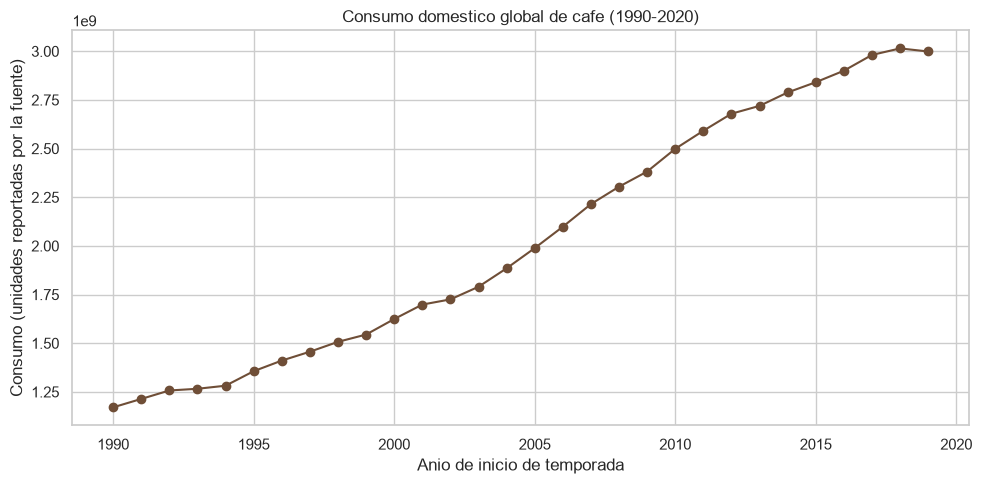

```
Crecimiento acumulado del consumo global 1990/91-2019/20: 156.2%
```

```python
global_by_year = df_long.groupby("Year_start")["Consumption"].sum().reset_index()

fig, ax = plt.subplots()
ax.plot(global_by_year["Year_start"], global_by_year["Consumption"], marker="o", color="#6f4e37")
ax.set_title("Consumo domestico global de cafe (1990-2020)")
ax.set_xlabel("Anio de inicio de temporada")
ax.set_ylabel("Consumo (unidades reportadas por la fuente)")
fig.tight_layout()
fig.savefig(CHARTS_DIR / "01_tendencia_global.png", dpi=150)
plt.show()

growth_total = (global_by_year["Consumption"].iloc[-1] / global_by_year["Consumption"].iloc[0] - 1) * 100
print(f"Crecimiento acumulado del consumo global 1990/91-2019/20: {growth_total:.1f}%")
```

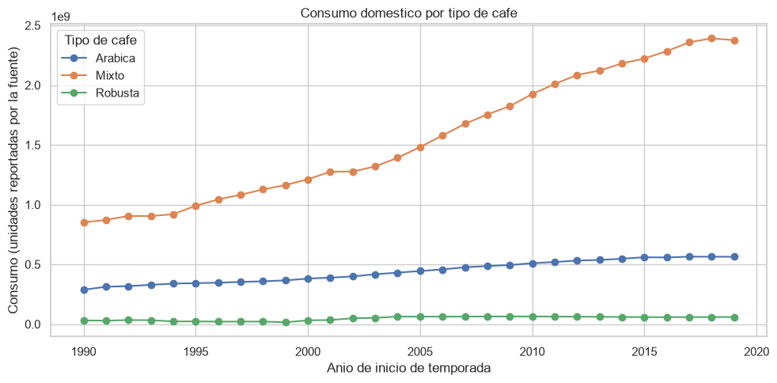

```python
by_type = df_long.groupby(["Year_start", "Coffee_type_grouped"])["Consumption"].sum().reset_index()

fig, ax = plt.subplots()
for t, g in by_type.groupby("Coffee_type_grouped"):
    ax.plot(g["Year_start"], g["Consumption"], marker="o", label=t)
ax.legend(title="Tipo de cafe")
ax.set_title("Consumo domestico por tipo de cafe")
ax.set_xlabel("Anio de inicio de temporada")
ax.set_ylabel("Consumo (unidades reportadas por la fuente)")
fig.tight_layout()
fig.savefig(CHARTS_DIR / "02_tendencia_por_tipo.png", dpi=150)
plt.show()
```

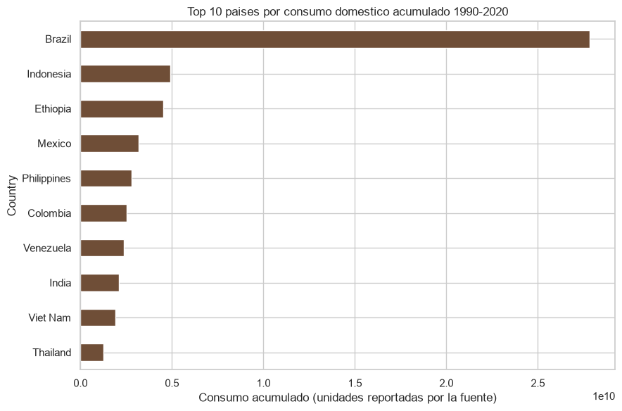

```
Country
Brazil         27824700000
Indonesia       4920480000
Ethiopia        4536540000
Mexico          3189660000
Philippines     2807280000
Colombia        2536776384
Venezuela       2386067999
India           2093460000
Viet Nam        1920928320
Thailand        1248600000
Name: Total_domestic_consumption, dtype: int64
```

```python
totals = df_wide.groupby("Country")["Total_domestic_consumption"].sum().sort_values(ascending=False)
top10 = totals.head(10)

fig, ax = plt.subplots(figsize=(9, 6))
top10.iloc[::-1].plot(kind="barh", ax=ax, color="#6f4e37")
ax.set_title("Top 10 paises por consumo domestico acumulado 1990-2020")
ax.set_xlabel("Consumo acumulado (unidades reportadas por la fuente)")
fig.tight_layout()
fig.savefig(CHARTS_DIR / "03_top10_paises.png", dpi=150)
plt.show()

top10
```

## 3. Crecimiento y ranking de paises (CAGR)

Regla de calculo del CAGR (evita divisiones por cero): se valida que exista al menos un valor positivo en la serie del pais. Si `1990/91` es 0, el CAGR se calcula desde el primer anio con valor positivo registrado. Si el ultimo anio (`2019/20`) es 0 (el pais dejo de reportar/perdio todo su consumo domestico) o si ningun anio de la serie es positivo, el CAGR se marca como `NaN` y el pais se excluye del ranking de crecimiento, pero se documenta aparte como caso especial en la seccion de anomalias.

```python
def compute_cagr(row: pd.Series):
    series = row[SEASON_COLS].astype(float)
    positive = series[series > 0]
    if positive.empty:
        return np.nan
    start_idx = positive.index[0]
    start_val = positive.iloc[0]
    end_val = series.iloc[-1]
    n_periods = SEASON_COLS.index(series.index[-1]) - SEASON_COLS.index(start_idx)
    if n_periods <= 0 or end_val <= 0:
        return np.nan
    return (end_val / start_val) ** (1 / n_periods) - 1

df_wide["CAGR"] = df_wide.apply(compute_cagr, axis=1)

def consumption_status(row: pd.Series):
    series = row[SEASON_COLS].astype(float)
    if (series > 0).sum() == 0:
        return "sin_datos"
    if series.iloc[-1] <= 0:
        return "interrumpido"
    return "activo"

df_wide["Consumption_status"] = df_wide.apply(consumption_status, axis=1)
print(df_wide["Consumption_status"].value_counts())
print(f"Paises excluidos del ranking de CAGR (CAGR = NaN): {df_wide['CAGR'].isna().sum()}")
```

```
Consumption_status
activo          52
sin_datos        2
interrumpido     1
Name: count, dtype: int64
Paises excluidos del ranking de CAGR (CAGR = NaN): 3
```

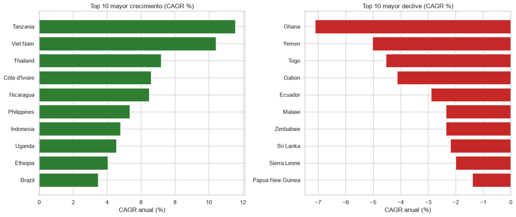

|  | Country | Coffee_type_grouped | CAGR |
| --- | --- | --- | --- |
| 19 | Tanzania | Mixto | 0.115416 |
| 53 | Viet Nam | Mixto | 0.104092 |
| 48 | Thailand | Mixto | 0.071687 |
| 25 | Côte d'Ivoire | Robusta | 0.065757 |
| 43 | Nicaragua | Arabica | 0.064797 |
| 18 | Philippines | Mixto | 0.053345 |
| 5 | Indonesia | Mixto | 0.047766 |
| 51 | Uganda | Mixto | 0.045445 |
| 29 | Ethiopia | Arabica | 0.040368 |
| 2 | Brazil | Mixto | 0.034617 |

```python
growth_ranking = (
    df_wide[["Country", "Coffee_type_grouped", "CAGR"]]
    .dropna(subset=["CAGR"])
    .sort_values("CAGR", ascending=False)
)
top_gainers = growth_ranking.head(10)
top_losers = growth_ranking.tail(10).sort_values("CAGR")

fig, axes = plt.subplots(1, 2, figsize=(14, 6))
axes[0].barh(top_gainers["Country"][::-1], top_gainers["CAGR"][::-1] * 100, color="#2e7d32")
axes[0].set_title("Top 10 mayor crecimiento (CAGR %)")
axes[0].set_xlabel("CAGR anual (%)")
axes[1].barh(top_losers["Country"][::-1], top_losers["CAGR"][::-1] * 100, color="#c62828")
axes[1].set_title("Top 10 mayor declive (CAGR %)")
axes[1].set_xlabel("CAGR anual (%)")
fig.tight_layout()
fig.savefig(CHARTS_DIR / "04_ranking_crecimiento.png", dpi=150)
plt.show()

top_gainers
```

## 4. Segmentacion de paises productores (clustering)

Se agrupan los 55 paises segun tres caracteristicas de su patron de consumo domestico: nivel promedio (log), crecimiento (CAGR) y volatilidad (desviacion estandar de las variaciones interanuales). Los 3 paises sin CAGR valido (`sin_datos` o `interrumpido`) se excluyen del clustering porque no tienen una senal de crecimiento comparable, y se reportan aparte. `KMeans` y `PCA` usan `random_state=42` para reproducibilidad.

```python
def yoy_std(row: pd.Series):
    series = row[SEASON_COLS].astype(float)
    pct = series.pct_change().replace([np.inf, -np.inf], np.nan).dropna()
    return pct.std()

df_wide["Volatility"] = df_wide.apply(yoy_std, axis=1)
df_wide["Level_mean"] = df_wide[SEASON_COLS].astype(float).mean(axis=1)

cluster_input = df_wide.dropna(subset=["CAGR", "Volatility"]).copy()
excluded_from_clustering = df_wide[~df_wide["Country"].isin(cluster_input["Country"])]["Country"].tolist()
print("Paises excluidos del clustering:", excluded_from_clustering)

features = cluster_input[["Level_mean", "CAGR", "Volatility"]].copy()
features["Level_mean"] = np.log1p(features["Level_mean"])

scaler = StandardScaler()
X = scaler.fit_transform(features)

sil_scores = {}
for k in range(2, 7):
    km = KMeans(n_clusters=k, random_state=RANDOM_STATE, n_init=10)
    labels = km.fit_predict(X)
    sil_scores[k] = silhouette_score(X, labels)

best_k = max(sil_scores, key=sil_scores.get)
print("Silhouette por k:", {k: round(v, 3) for k, v in sil_scores.items()})
print("k elegido:", best_k)

kmeans = KMeans(n_clusters=best_k, random_state=RANDOM_STATE, n_init=10)
cluster_input["Cluster"] = kmeans.fit_predict(X)
```

```
Paises excluidos del clustering: ['Zambia', 'Equatorial Guinea', 'Nepal']
```

```
Silhouette por k: {2: 0.332, 3: 0.408, 4: 0.323, 5: 0.347, 6: 0.334}
k elegido: 3
```

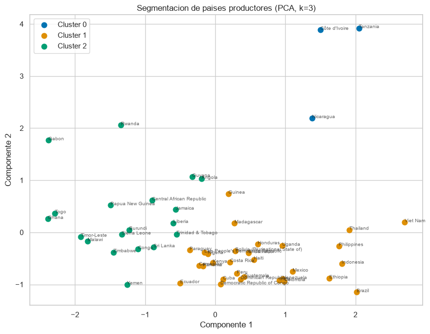

```python
pca = PCA(n_components=2, random_state=RANDOM_STATE)
coords = pca.fit_transform(X)
cluster_input["PC1"] = coords[:, 0]
cluster_input["PC2"] = coords[:, 1]

fig, ax = plt.subplots(figsize=(9, 7))
palette = sns.color_palette("colorblind", n_colors=best_k)
for c in sorted(cluster_input["Cluster"].unique()):
    sub = cluster_input[cluster_input["Cluster"] == c]
    ax.scatter(sub["PC1"], sub["PC2"], label=f"Cluster {c}", color=palette[c], s=60)
for _, r in cluster_input.iterrows():
    ax.annotate(r["Country"], (r["PC1"], r["PC2"]), fontsize=7, alpha=0.7)
ax.set_title(f"Segmentacion de paises productores (PCA, k={best_k})")
ax.set_xlabel("Componente 1")
ax.set_ylabel("Componente 2")
ax.legend()
fig.tight_layout()
fig.savefig(CHARTS_DIR / "05_clusters_pca.png", dpi=150)
plt.show()
```

```python
cluster_profile = cluster_input.groupby("Cluster").agg(
    n_paises=("Country", "count"),
    nivel_promedio=("Level_mean", "mean"),
    cagr_promedio=("CAGR", "mean"),
    volatilidad_promedio=("Volatility", "mean"),
    paises=("Country", lambda s: ", ".join(sorted(s))),
).reset_index()
cluster_profile["cagr_promedio"] = (cluster_profile["cagr_promedio"] * 100).round(2)
cluster_profile["volatilidad_promedio"] = (cluster_profile["volatilidad_promedio"] * 100).round(2)
cluster_profile
```

|  | Cluster | n_paises | nivel_promedio | cagr_promedio | volatilidad_promedio | paises |
| --- | --- | --- | --- | --- | --- | --- |
| 0 | 0 | 3 | 8.737617e+06 | 8.20 | 80.85 | Côte d'Ivoire, Nicaragua, Tanzania |
| 1 | 1 | 30 | 6.671273e+07 | 2.03 | 7.92 | Bolivia (Plurinational State of), Brazil, Came... |
| 2 | 2 | 19 | 6.279428e+05 | -1.29 | 21.66 | Angola, Burundi, Central African Republic, Con... |

## 5. Forecasting de consumo domestico

Con solo 30 puntos anuales por pais, ajustar 55 modelos individuales finos arriesga sobreajuste. Se compara, mediante backtesting sobre la serie global (entrenando hasta 2014/15 y evaluando 2015/16-2019/20), un modelo de tendencia lineal contra un modelo Holt (suavizado exponencial con tendencia aditiva, sin estacionalidad por tratarse de datos anuales). El metodo con menor error (MAPE) en el backtest se usa despues para proyectar 5 anios (2020/21-2024/25) sobre: el agregado global, cada tipo de cafe agregado, y los 10 paises de mayor consumo (no se proyectan los 55 paises individualmente, para no dar una falsa sensacion de precision).

```python
def linear_forecast(values: np.ndarray, periods: int):
    x = np.arange(len(values))
    coeffs = np.polyfit(x, values, 1)
    future_x = np.arange(len(values), len(values) + periods)
    return np.polyval(coeffs, future_x)

def holt_forecast(values: np.ndarray, periods: int):
    model = ExponentialSmoothing(values, trend="add", damped_trend=True, initialization_method="estimated")
    fit = model.fit()
    return fit.forecast(periods)

def mape(y_true, y_pred):
    y_true, y_pred = np.array(y_true), np.array(y_pred)
    mask = y_true != 0
    return np.mean(np.abs((y_true[mask] - y_pred[mask]) / y_true[mask])) * 100

global_series = global_by_year.set_index("Year_start")["Consumption"].values
train, test = global_series[:-5], global_series[-5:]

lin_pred = linear_forecast(train, 5)
holt_pred = holt_forecast(train, 5)

mape_lin = mape(test, lin_pred)
mape_holt = mape(test, holt_pred)
print(f"MAPE backtest tendencia lineal: {mape_lin:.2f}%")
print(f"MAPE backtest Holt (tendencia amortiguada): {mape_holt:.2f}%")

best_method = "linear" if mape_lin <= mape_holt else "holt"
print("Metodo elegido para las proyecciones:", best_method)

def forecast_series(values: np.ndarray, periods: int = 5):
    if best_method == "linear":
        return linear_forecast(values, periods)
    return holt_forecast(values, periods)
```

```
MAPE backtest tendencia lineal: 1.68%
MAPE backtest Holt (tendencia amortiguada): 1.48%
Metodo elegido para las proyecciones: holt
```

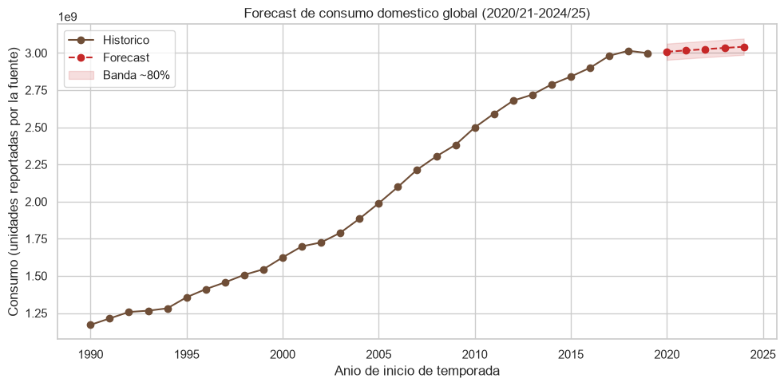

```python
FUTURE_SEASONS = ["2020/21", "2021/22", "2022/23", "2023/24", "2024/25"]

global_forecast = forecast_series(global_series, 5)
residual_std = np.std(test - (lin_pred if best_method == "linear" else holt_pred))

fig, ax = plt.subplots()
ax.plot(global_by_year["Year_start"], global_by_year["Consumption"], marker="o", label="Historico", color="#6f4e37")
future_years = list(range(2020, 2025))
ax.plot(future_years, global_forecast, marker="o", linestyle="--", label="Forecast", color="#c62828")
ax.fill_between(future_years, global_forecast - 1.28 * residual_std, global_forecast + 1.28 * residual_std,
                 color="#c62828", alpha=0.15, label="Banda ~80%")
ax.legend()
ax.set_title("Forecast de consumo domestico global (2020/21-2024/25)")
ax.set_xlabel("Anio de inicio de temporada")
ax.set_ylabel("Consumo (unidades reportadas por la fuente)")
fig.tight_layout()
fig.savefig(CHARTS_DIR / "06_forecast_global.png", dpi=150)
plt.show()

forecast_results = {
    "global": {
        "metodo": best_method,
        "mape_backtest_pct": round(mape_lin if best_method == "linear" else mape_holt, 2),
        "seasons": FUTURE_SEASONS,
        "valores": [round(v, 0) for v in global_forecast.tolist()],
        "banda_80_inferior": [round(v, 0) for v in (global_forecast - 1.28 * residual_std).tolist()],
        "banda_80_superior": [round(v, 0) for v in (global_forecast + 1.28 * residual_std).tolist()],
    }
}
```

```python
for t, g in by_type.groupby("Coffee_type_grouped"):
    series = g.set_index("Year_start")["Consumption"].reindex(range(1990, 2020)).values
    fc = forecast_series(series, 5)
    forecast_results[t.lower()] = {
        "metodo": best_method,
        "seasons": FUTURE_SEASONS,
        "valores": [round(v, 0) for v in fc.tolist()],
    }

top10_countries = totals.head(10).index.tolist()
for country in top10_countries:
    series = df_long[df_long["Country"] == country].set_index("Year_start")["Consumption"].reindex(range(1990, 2020)).values
    fc = forecast_series(series, 5)
    forecast_results[country.lower()] = {
        "metodo": best_method,
        "seasons": FUTURE_SEASONS,
        "valores": [round(v, 0) for v in fc.tolist()],
    }

print("Entidades con forecast calculado:", list(forecast_results.keys()))
```

```
Entidades con forecast calculado: ['global', 'arabica', 'mixto', 'robusta', 'brazil', 'indonesia', 'ethiopia', 'mexico', 'philippines', 'colombia', 'venezuela', 'india', 'viet nam', 'thailand']
```

## 6. Indice de presion de precios (SIMULADO)

El dataset no incluye precios de mercado. Para responder al pedido explicito del reto de "rangos de precios futuros" sin inventar datos de mercado como si fueran reales, se construye un indice ilustrativo con metodologia transparente, disenado como un oscilador de presion (no como un nivel de precio compuesto, que explotaria matematicamente si se capitaliza un crecimiento sostenido durante 30 anios):

`Indice_t = 100 + k * 100 * (crecimiento_consumo_global_t - crecimiento_promedio_historico) + ruido_t`

Intuicion: si el consumo domestico global crece un anio por encima de su promedio historico, una porcion mayor de la produccion se queda en el pais de origen ese anio, ajustando el excedente exportable disponible por debajo de lo habitual, lo que se traduce en el indice como una senal de mayor presion al alza sobre precios (valor por encima de 100); si crece por debajo de su promedio historico, la senal es de menor presion (valor por debajo de 100). `k` es una constante de sensibilidad ilustrativa (no calibrada con datos de mercado reales) y `ruido_t` es una perturbacion aleatoria pequena (`random_state=42`) que representa la variabilidad real de precios que este unico indicador no puede explicar.

Aviso explicito: este indice NO son precios reales de cafe, es una simulacion con fines demostrativos, acotada alrededor de 100 en vez de una serie que se dispara, para que su escala se pueda leer como una senal de tension relativa y no como un nivel de precio en dolares. Para una version productiva se requeriria integrar datos reales, por ejemplo el indicador compuesto de la OIC o los futuros de cafe de ICE.

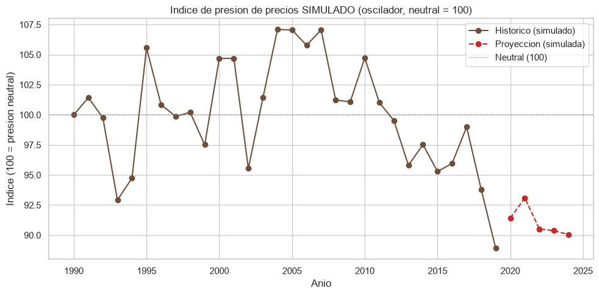

```
{'aviso': 'Indice ilustrativo simulado (oscilador de presion), NO son precios de mercado reales.',
 'neutral': '100 = presion neutral (crecimiento de consumo igual al promedio historico 1990/91-2019/20)',
 'k_sensibilidad': 3.0,
 'valor_2019_20': np.float64(88.9),
 'proyeccion_seasons': ['2020/21', '2021/22', '2022/23', '2023/24', '2024/25'],
 'proyeccion_valores': [np.float64(91.4),
  np.float64(93.1),
  np.float64(90.5),
  np.float64(90.4),
  np.float64(90.0)]}
```

```python
rng = np.random.default_rng(RANDOM_STATE)
K_SENSITIVITY = 3.0
NOISE_STD_POINTS = 1.0

global_growth = global_by_year["Consumption"].pct_change().dropna().values
mean_hist_growth = global_growth.mean()

index_values = [100.0]
for g in global_growth:
    noise = rng.normal(loc=0.0, scale=NOISE_STD_POINTS)
    deviation = g - mean_hist_growth
    next_val = 100 + K_SENSITIVITY * 100 * deviation + noise
    index_values.append(next_val)
# index_values queda alineado con global_by_year (primer anio = 100 por definicion)

price_index_hist = pd.DataFrame({"Year_start": global_by_year["Year_start"], "Indice_simulado": index_values})

# Proyeccion del indice usando el forecast de consumo global ya calculado, con la misma
# referencia de crecimiento promedio historico (no el promedio del forecast) para que la
# proyeccion sea comparable con la serie historica.
future_growth = np.diff(np.concatenate([[global_series[-1]], global_forecast])) / np.concatenate([[global_series[-1]], global_forecast])[:-1]
index_future = []
for g in future_growth:
    noise = rng.normal(loc=0.0, scale=NOISE_STD_POINTS)
    deviation = g - mean_hist_growth
    index_future.append(100 + K_SENSITIVITY * 100 * deviation + noise)

fig, ax = plt.subplots()
ax.plot(price_index_hist["Year_start"], price_index_hist["Indice_simulado"], marker="o", label="Historico (simulado)", color="#6f4e37")
ax.plot(future_years, index_future, marker="o", linestyle="--", label="Proyeccion (simulada)", color="#c62828")
ax.axhline(100, color="gray", linestyle=":", linewidth=1, label="Neutral (100)")
ax.legend()
ax.set_title("Indice de presion de precios SIMULADO (oscilador, neutral = 100)")
ax.set_xlabel("Anio")
ax.set_ylabel("Indice (100 = presion neutral)")
fig.tight_layout()
fig.savefig(CHARTS_DIR / "07_indice_precio_simulado.png", dpi=150)
plt.show()

price_index_summary = {
    "aviso": "Indice ilustrativo simulado (oscilador de presion), NO son precios de mercado reales.",
    "neutral": "100 = presion neutral (crecimiento de consumo igual al promedio historico 1990/91-2019/20)",
    "k_sensibilidad": K_SENSITIVITY,
    "valor_2019_20": round(index_values[-1], 1),
    "proyeccion_seasons": FUTURE_SEASONS,
    "proyeccion_valores": [round(v, 1) for v in index_future],
}
price_index_summary
```

## 7. Deteccion de anomalias y eventos relevantes

```python
df_long["YoY_pct"] = df_long.groupby("Country")["Consumption"].pct_change()

def zscore(s: pd.Series):
    std = s.std()
    if std == 0 or np.isnan(std):
        return pd.Series(np.nan, index=s.index)
    return (s - s.mean()) / std

df_long["YoY_zscore"] = df_long.groupby("Country")["YoY_pct"].transform(zscore)

anomalies = df_long[df_long["YoY_zscore"].abs() > 2.5].copy()
anomalies = anomalies.sort_values("YoY_zscore", key=lambda s: s.abs(), ascending=False)
anomalies_top = anomalies[["Country", "Season", "Consumption", "YoY_pct", "YoY_zscore"]].head(15)
anomalies_top
```

|  | Country | Season | Consumption | YoY_pct | YoY_zscore |
| --- | --- | --- | --- | --- | --- |
| 359 | Democratic Republic of Congo | 2019/20 | 11880000 | -0.010000 | -5.199469 |
| 1143 | Paraguay | 1993/94 | 1200000 | 0.333333 | 5.199469 |
| 873 | Liberia | 1993/94 | 300000 | 0.666667 | 5.199469 |
| 939 | Malawi | 1999/00 | 60000 | -0.500000 | -5.199469 |
| 310 | Côte d'Ivoire | 2000/01 | 19000020 | 5.333340 | 5.199469 |
| 661 | Haiti | 1991/92 | 19800000 | 0.500000 | 5.187994 |
| 1322 | Tanzania | 1992/93 | 1152000 | 4.485714 | 5.062541 |
| 530 | Gabon | 2010/11 | 56820 | 2.788000 | 4.974728 |
| 1021 | Nicaragua | 1991/92 | 8280000 | 3.058824 | 4.928063 |
| 1051 | Nigeria | 1991/92 | 2145000 | 0.300000 | 4.824748 |
| 1218 | Philippines | 2008/09 | 103200000 | 0.622642 | 4.764608 |
| 602 | Guinea | 1992/93 | 3750000 | 1.500000 | 4.697488 |
| 1626 | Zimbabwe | 1996/97 | 240000 | -0.393939 | -4.555541 |
| 1529 | Venezuela | 2019/20 | 76500000 | -0.177419 | -4.364463 |
| 110 | Burundi | 2010/11 | 120000 | 0.429593 | 4.095772 |

Casos estructurales relevantes que no siempre aparecen como pico puntual pero son informacion clave para negocio:

Zambia: el consumo domestico reportado cae a 0 de forma sostenida desde 2009/10 hasta 2019/20 (11 temporadas seguidas en cero), tras venir de un rango de 36.000-90.000 unidades. Es una interrupcion de reporte o de actividad, no una fluctuacion normal; se recomienda verificar con la fuente antes de usar este pais en decisiones comerciales.

Equatorial Guinea y Nepal: no tienen ningun valor positivo registrado en las 30 temporadas. Es probable que sean paises sin consumo domestico material o sin cobertura de reporte de la fuente; se excluyen de los rankings de crecimiento y del clustering por no tener senal.

Estos tres casos se marcaron automaticamente con `Consumption_status` en la seccion 3.

## 8. Conclusiones y recomendaciones de negocio

Consumo global: el consumo domestico global crecio de forma sostenida entre 1990/91 y 2019/20 (ver seccion 2), lo que estructuralmente reduce el excedente exportable disponible en el tiempo si la produccion no crece al mismo ritmo.

Concentracion: un grupo reducido de paises (Brasil, Indonesia, Etiopia, Mexico, Filipinas, Colombia, Venezuela, India, Vietnam, Tailandia) concentra la mayor parte del consumo domestico historico acumulado; son los mercados donde una variacion en su consumo interno tiene mayor impacto en la oferta exportable global.

Segmentacion: los clusters de la seccion 4 permiten priorizar de forma diferenciada. Los paises del segmento de mayor crecimiento absorben cada vez mas de su propia produccion (senal de alerta temprana para asegurar contratos de suministro a largo plazo antes de que su excedente exportable se reduzca mas). Los paises del segmento en declive o estable liberan (o mantienen) mas excedente exportable en el tiempo, y son candidatos a fortalecer relaciones comerciales de abastecimiento.

Forecast: la proyeccion a 2024/25 (seccion 5) da una primera estimacion cuantitativa para planear volumenes de compra/exportacion a mediano plazo, con una banda de incertidumbre explicita en vez de un numero unico.

Precios: el indice de presion de precios (seccion 6) es una prueba de concepto que conecta la dinamica de consumo con una senal de precio; para uso real en decisiones comerciales debe sustituirse o calibrarse con datos de mercado reales (ej. indicador compuesto OIC, futuros ICE), no usarse tal cual.

Calidad de datos: se recomienda a producto/datos verificar los 3 casos senalados en la seccion 7 (Zambia, Equatorial Guinea, Nepal) con la fuente original antes de tomarlos como insumo de decisiones comerciales.

## 9. Bonus: chatbot con IA generativa

Se desarrollo una demo funcional en `bonus_chatbot/chatbot.py`: un chatbot de linea de comandos que responde preguntas en lenguaje natural sobre este analisis (tendencias, ranking de crecimiento, clusters, forecast, indice de precios simulado), usando un patron de tool-use con el modelo Claude sobre el resumen de datos que esta celda exporta a `outputs/analysis_summary.json`. Si no hay una API key de Anthropic configurada, el script cae automaticamente a un modo mock/dry-run con un menu de preguntas frecuentes precanned, para que se pueda ejecutar sin credenciales. Ver `bonus_chatbot/README.md` para instrucciones y la seccion 10 del informe (`informe_solucion.md`) para la propuesta completa de arquitectura y extensiones futuras (RAG, integracion Slack/Teams, narrativas automaticas, alertas proactivas).

```python
countries_summary = []
for _, row in df_wide.iterrows():
    countries_summary.append({
        "country": row["Country"],
        "coffee_type": row["Coffee_type_grouped"],
        "total_historico": int(row["Total_domestic_consumption"]),
        "cagr": None if pd.isna(row["CAGR"]) else round(float(row["CAGR"]), 4),
        "consumption_status": row["Consumption_status"],
        "cluster": None,
    })

cluster_map = dict(zip(cluster_input["Country"], cluster_input["Cluster"].astype(int)))
for c in countries_summary:
    if c["country"] in cluster_map:
        c["cluster"] = cluster_map[c["country"]]

clusters_summary = {}
for _, r in cluster_profile.iterrows():
    clusters_summary[str(int(r["Cluster"]))] = {
        "n_paises": int(r["n_paises"]),
        "cagr_promedio_pct": float(r["cagr_promedio"]),
        "volatilidad_promedio_pct": float(r["volatilidad_promedio"]),
        "paises": r["paises"],
    }

analysis_summary = {
    "countries": countries_summary,
    "clusters": clusters_summary,
    "forecast": forecast_results,
    "price_index": price_index_summary,
    "excluidos_clustering": excluded_from_clustering,
}

with open(OUTPUTS_DIR / "analysis_summary.json", "w", encoding="utf-8") as f:
    json.dump(analysis_summary, f, ensure_ascii=False, indent=2)

print("Resumen exportado a", OUTPUTS_DIR / "analysis_summary.json")
```

```
Resumen exportado a C:\Users\arroy\Downloads\PRUEBA JOE NTT DATA\outputs\analysis_summary.json
```